# ESM 204 Homework 4

Justine Lang

2023-05-31

```r
damages_df <- read_csv(here("damages.csv")) %>%
  mutate(warming_sq = warming^2)

warming <- read_csv(here("warming.csv"))
```

## Question 1

Using damages.csv, estimate a quadratic damage function relating the dollar value of damages to the change in global mean temperature. Omit an intercept term; damages by construction must equal zero when there is no climate change. Plot your estimated damage function, overlaid with a scatterplot of the underlying data.

```r
### Create climate damages model with 0 intercept

damages_lm <- lm(damages ~ warming + warming_sq -1, data = damages_df)

coeff_1 <- damages_lm$coefficients[[1]]
coeff_2 <- damages_lm$coefficients[[2]]

### Make df with fitted values

damages_pred <- damages_lm$model %>%
  mutate(fitted_dam = damages_lm$fitted.values)
```

```r
### Damages function

damage_fun <- function(warming)
  {dam <- (damages_lm$coefficients[1]* (warming)) +
    (damages_lm$coefficients[2] * (warming^2))
  return(dam)}

### Testing
# damage_fun(0.69)
```

Equation: $Damages$ = -2.04665^{12} $Warming$ + 3.8807637^{13} $Warming^2$.

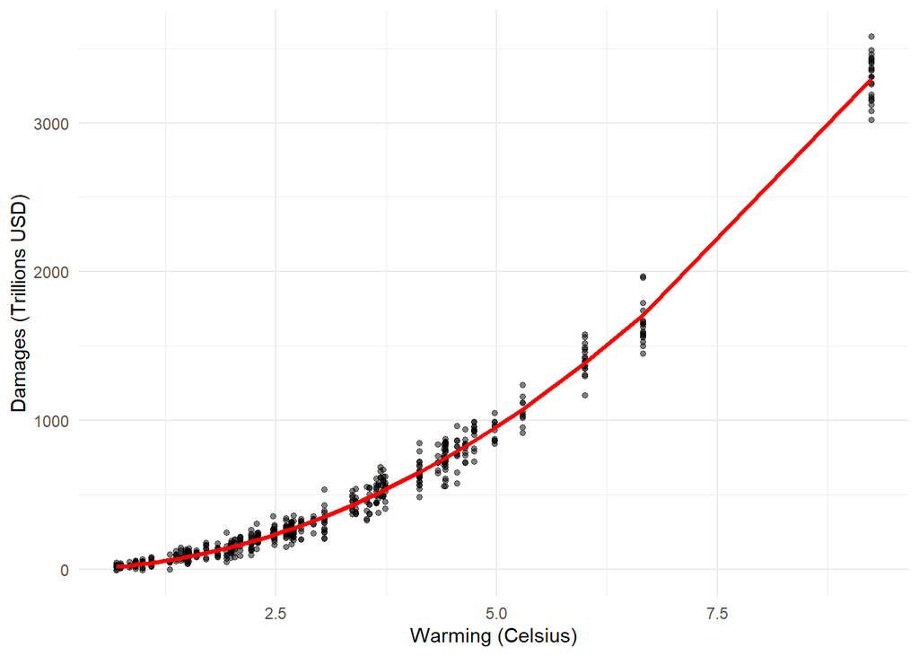

Figure 1: Estimated damages in trillions USD per additional unit of warming (degrees Celsius).

```r
### Plot

ggplot(data = damages_pred, aes(x = warming)) +
  geom_point(aes(y = damages/1E12), size = 1.2, alpha = 0.5) +
  geom_line(aes(y = fitted_dam/1E12), size = 1.2, color = 'red') +
  theme_minimal() +
  labs(x = "Warming (Celsius)", y = "Damages (Trillions USD)")
```

## Question 2

Use warming.csv and your estimated damage function to predict damages in each year under the baseline climate trajectory and under the pulse scenario. Make four plots: (1) damages over time without the pulse, (2) damages over time with the pulse, (3) the difference in damages over time that arises from the pulse, and (4) the difference in damages over time from the pulse per ton of CO2 (you can assume that each ton of the pulse causes the same amount of damage).

```r
pulse <- 35E9
```

```r
### Create a df of the different warming scenarios, with and without the pulse

warming_scen <- warming %>%
  mutate(damages_base = damage_fun(warming_baseline)) %>%
  mutate(damages_pulse = damage_fun(warming_pulse)) %>%
  mutate(damages_diff = damages_pulse - damages_base) %>%
  mutate(damages_perton = damages_diff/pulse)
```

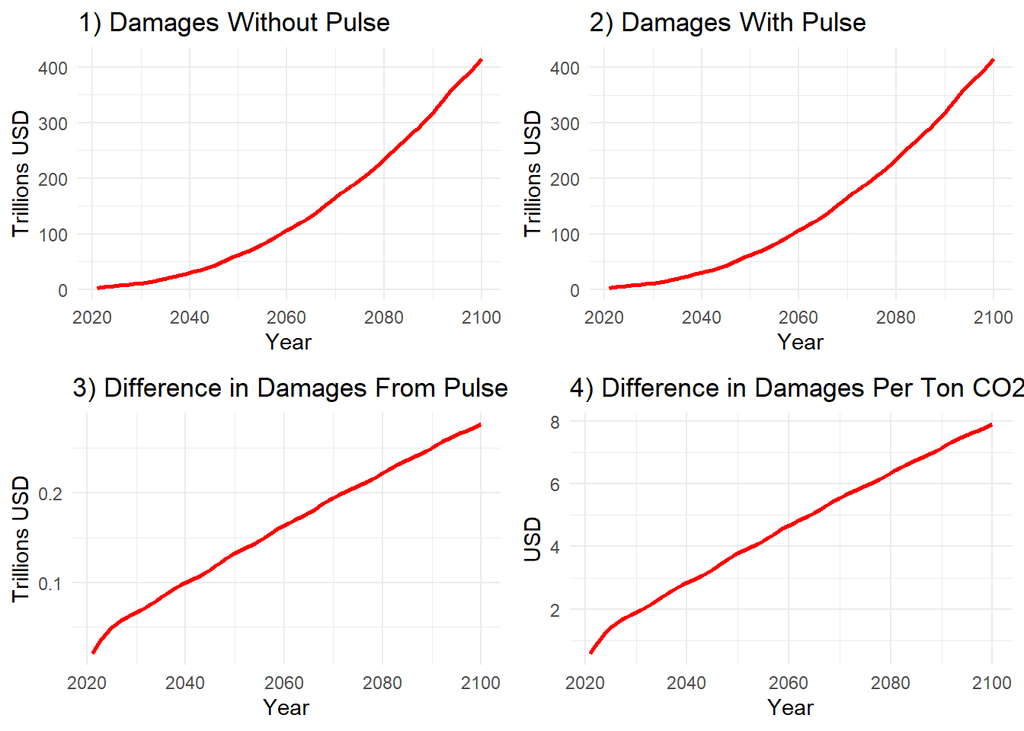

Figure 2: Estimated climate change damages under different warming scenarios.

```r
### Plot 1: Damages over time without the pulse

damages_p1 <- ggplot(data = warming_scen) +
  geom_line(aes(x = year, y = damages_base/1E12), size = 1, color = 'red') +
  theme_minimal() +
  labs(title = "1) Damages Without Pulse", x = "Year", y = "Trillions USD")

### Plot 2: Damages over time with the pulse

damages_p2 <- ggplot(data = warming_scen) +
  geom_line(aes(x = year, y = damages_pulse/1E12), size = 1, color = 'red') +
  theme_minimal() +
  labs(title = "2) Damages With Pulse", x = "Year", y = "Trillions USD")

### Plot 3: Difference in damages over time that arises from the pulse

damages_p3 <- ggplot(data = warming_scen) +
  geom_line(aes(x = year, y = damages_diff/1E12), size = 1, color = 'red') +
  theme_minimal() +
  labs(title = "3) Difference in Damages From Pulse", x = "Year", y = "Trillions USD")

### Plot 4: Difference in damages over time from the pulse per ton of CO2

damages_p4 <- ggplot(data = warming_scen) +
  geom_line(aes(x = year, y = damages_perton), size = 1, color = 'red') +
  theme_minimal() +
  labs(title = "4) Difference in Damages Per Ton CO2", x = "Year", y = "USD")

### Combine plots

plot_grid(damages_p1, damages_p2, damages_p3, damages_p4)
```

## Question 3

The SCC is defined as the present discounted value of the stream of future damages caused by one additional ton of CO2. The Obama Administration used a discount rate of 3% to discount damages. The recent EPA update uses a discount rate that changes over time, but starts at 2%. Calculate and make a plot of the SCC (y-axis) against the discount rate (x-axis) for discount rates ranging from 1% to 8%.

```r
### Create range of discount rates (r) from 1% to 8% in 0.05% increments

r <- seq(0.01, 0.08, 0.005)

### Defining additional damage

add_damage <- warming_scen$damages_perton

### Function to calculate damages in present value

damage_pv_fun <- function(add_damage, r){
  add_damage_pv = sum(add_damage/((1 + r)^c(1:length(add_damage))))
  return(add_damage_pv)
}
```

```r
### Create SCC and discount rate df, following Patrick's advice

scc <- numeric()

for(i in 1:length(r)){
  scc[i] <- damage_pv_fun(add_damage, r[i])
}

scc_df <- data.frame(scc) %>%
  mutate(discount_rate = r*100)
```

```r
### Ramsey Rule discount rate (from Question 4)

ramsey = 0.001 + 2*0.01

ramsey_damage <- damage_pv_fun(add_damage, ramsey) ### 141.3357
```

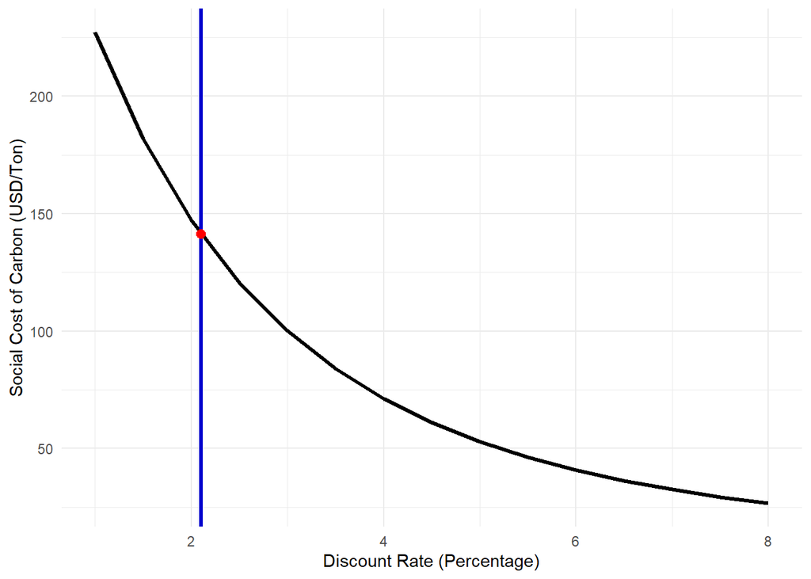

Figure 3: Black line is the social cost of carbon (SCC) for discount rates ranging from 1% to 8%. The red point is the SCC under the Ramsey Rule scenario (blue line).

```r
### Plot

ggplot(data = scc_df) +
  geom_line(aes(x = discount_rate, y = scc), size = 1.2) +
  theme_minimal() +
  labs(x = "Discount Rate (Percentage)", y = "Social Cost of Carbon (USD/Ton)") +
  geom_vline(xintercept = ramsey*100, size = 1.2, color = "blue3") +
  geom_point(aes(x = ramsey*100, y = ramsey_damage), size = 2.5, color = 'red')
```

## Question 4

The National Academies of Sciences, Engineering, and Medicine advised the government in a 2017 report to use the Ramsey Rule when discounting within the SCC calculation, a recommendation the EPA considered. Recall the Ramsey Rule: r = p + ng. Using p = 0.001, n = 2, and g = 0.01, what is the SCC? Locate this point on your graph from above.

**With a Ramsey Rule discount rate of 0.021, or roughly 2.1%, the SCC is around $141.34.** This point is shown on the graph above.

## Question 5

Now suppose there are two possible climate policies that can be pursued. Policy A is business as usual emissions, without any substantial climate change mitigation. Policy B is to take immediate and strong action on climate change. Use these facts:

• If you undertake Policy A there are two possible outcomes. Either warming will occur as in the “baseline” (i.e. “no-pulse”) dataset above (this happens with probability 0.5) or warming each year will be 1.5 times that in the “baseline” dataset (with probability 0.5).

• Under Policy B, warming will continue until 2050 as in the “baseline” dataset, and then will stabilize at 1.29 degrees and stay that way forever.

• Society is risk neutral

• Use a discount rate of 2%

**What is the expected present value of damages up to 2100 under Policy A? What is the expected present value of damages up to 2100 under Policy B?**

The expected present value of damages under Policy A is $6314.83 trillion. The expected present value of damages under Policy B is $1620.31 trillion.

**Suppose undertaking Policy A costs zero and undertaking Policy B costs X. How large could X be for it to still make economic sense to pursue Policy B instead of Policy A?**

When society is risk neutral, $E(U(x)) = U(E(x))$. It would make economic sense to pursue Policy B until $U(E(A)) = U(E(B))$. In other words, it would make economic sense to pursue Policy B until $-\$6314.83 = -\$1620.31 - X$ or $X = \$4694.52$.

**Qualitatively, how would your answer change if society were risk averse?**

If society is risk averse, then E(U(x)) < U(E(x)). In this case, E(U(A)) < U(B) when X = $4694.52. It is difficult to tell exactly what society’s preferences are from this information, but we can estimate that a risk adverse society will be even more inclined to prefer Policy B, which has a more certain outcome, for a cost greater than $4694.52, at least for a bit.

```r
### Creating a new df because I need to think through this without functions

### Remember B/(1 + r)^t  ### Try pmin

policy_scen <- warming %>%
  mutate(warming_A1 = warming_baseline) %>%
  mutate(warming_A2 = warming_baseline * 1.5) %>%
  mutate(warming_B1 = warming_baseline) %>%
  mutate(warming_B2 = 1.29) %>%
  mutate(warming_B = pmin(warming_B1, warming_B2)) %>%
  mutate(damages_A1 = (coeff_1*warming_A1 + coeff_2*warming_A1^2)/((1.02)^(year-2022))) %>%
  mutate(damages_A2 = (coeff_1*warming_A2 + coeff_2*warming_A2^2)/((1.02)^(year-2022))) %>%
  mutate(damages_B = (coeff_1*warming_B + coeff_2*warming_B^2)/((1.02)^(year-2022)))
```

```r
### Expected value: E(x) = pa A + pB B

ev_A <- 0.5*sum(policy_scen$damages_A1) + 0.5*sum(policy_scen$damages_A2)
val_B <- sum(policy_scen$damages_B)

# ev_A/1E12 ### 6314.828
# val_B/1E12 ### 1620.307
```

```r
### When risk neutral, E(U(A)) = U(E(A))

### Policy A: U(A) = U(-$6314.83). Policy B: U(B) = U(-$1620.31 - X)

### Cost scenario

x <- seq(0, 8000, length.out = 100)

policy_cost <- tibble(X = x, cost_a = 6314.83, cost_b = 1620.31 + x)
```

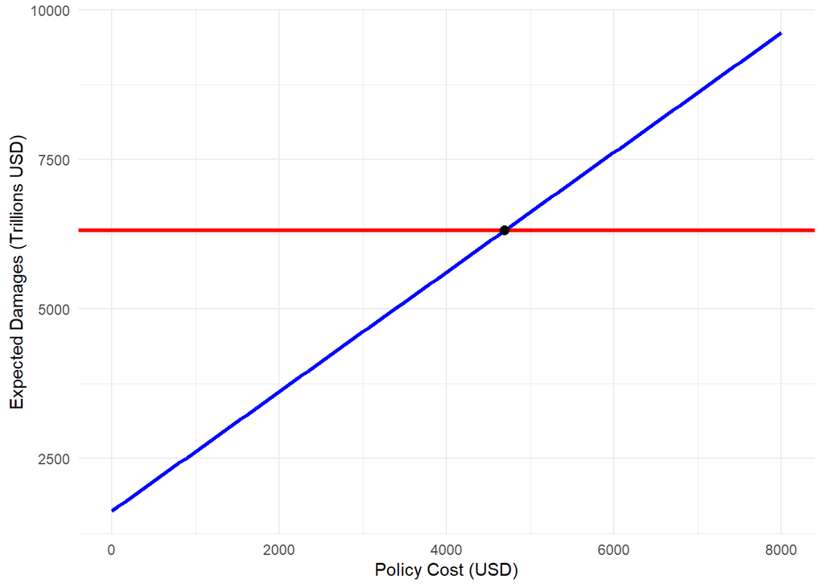

Figure 4: Expected costs under two policy scenarios. The red line represents Policy A. The blue line represents Policy B. The expected costs of the policies are equal where the lines intercept at the black dot.

```r
### Plot

ggplot(policy_cost) +
  geom_line(aes(x = X, y = cost_b), size = 1.2, color = 'blue') +
  geom_hline(yintercept = 6314.83, size = 1.2, color = 'red')  +
  geom_point(aes(x = 4694.52, y = 6314,83), size = 2.5) +
  theme_minimal() +
  labs(y = "Expected Damages (Trillions USD)", x = "Policy Cost (USD)")
```